# IAT LANG - gender-genius

Molly Lewis

2018-06-28

Study 2 data only. I’m controling for block order, and also including median country age as a covariate, because that seems to matter from other analyses we’ve done.

Take aways:

- when datasets are combined there’s no effect
- theres a trend when you look at only the turk data, controling for order
- residualizing out order, age, and sex doesn’t change much
- ggi marginally predicts language iat

```r
MINPARTICIPANTS <- 8
```

## Language data

```r
IAT_lang_full_path <- "genius_effect_sizes_google_full.csv"
IAT_lang_restricted_path <- "genius_effect_sizes_google_restricted.csv"
IAT_lang_restricted_path2 <- "genius_effect_sizes_google_restricted2.csv"
lang_key <- read_tsv("language_name_to_google.csv")
```

I calculated language IAT as in Caliskan et al (2017) for 40 languages in the behavioral data set, using translations from Google Translate. The restricted word list and full word lists effect sizes are highly correlated, so in the following analysis, I ony look at the effect sizes calculated from the restricted set.

## Behavioral data

```r
# Study 2
IAT_behavioral_path1 <-"../../data/IAT/Gender-Genius/InternationalIAT_LanguageData.csv"

IAT_behavioral_path_raw1 <- read_csv(IAT_behavioral_path1)

IAT_behavioral_tidy1 <- IAT_behavioral_path_raw1 %>%
  mutate(lang1 = tolower(PrimaryLanguage),
         #lang2 = tolower(lang_other_clean),
         Gender = tolower(Gender),
         subid = as.factor(1:n()))  %>%
  rename(iat_score = IATScore,
         gender = Gender,
         age = Age,
         country = Country,
        # ses = SES,
         condition = ConditionC,
         conservatism = Conservatism,
         status = Status,
         children = Children) %>%
  mutate(lang = ifelse(lang1 == "other", lang2, lang1)) %>%
       #  region = as.factor(countrycode::countrycode(country, "country.name", "region"))) %>%
  left_join(lang_key %>% select(language_code, lang)) %>%
  mutate_if(is.character, as.factor) %>%
  mutate(condition = as.factor(condition),
         log_age = log(age)) %>%
  select(subid, iat_score, lang, language_code, gender, condition, log_age, country, conservatism, status, children)


## Study1
IAT_behavioral_path2 <- "../../data/IAT/Gender-Genius/IAT_Study1_Combined_Master_Dataset_LanguageData.csv"

IAT_behavioral_path_raw2 <- read_csv(IAT_behavioral_path2)

IAT_behavioral_tidy2 <- IAT_behavioral_path_raw2 %>%
  mutate(lang = tolower(PrimaryLanguage),
         Gender = tolower(Gender),
         subid = as.factor(SubjectID))  %>%
  rename(iat_score = IATScore,
         gender = Gender,
         age = Age,
         country = Country,
         condition = Condition,
         #sexism = Sexism,
         #race = Race,
         #politicalparty = PoliticalParty,
         conservatism = Conservatism,
         status = Status,
         children = Children)%>%
         #income = Income) %>%
  left_join(lang_key %>% select(language_code, lang)) %>%
  mutate_if(is.character, as.factor) %>%
  mutate(condition = as.factor(condition),
         conservatism = as.factor(conservatism),
         children = as.numeric(children),
         log_age = log(age)) %>%
  select(subid, iat_score, lang, language_code, gender, condition, log_age, country, conservatism, status, children)

IAT_behavioral_tidy <- bind_rows(IAT_behavioral_tidy1, IAT_behavioral_tidy2)
IAT_behavioral_tidy <- IAT_behavioral_tidy1
```

Let’s residualize out order, age and gender, as in career, and add in mean country age, and objective bias measures

```r
# add residuals
mod <- lm(iat_score ~ as.factor(gender)   + log_age + as.factor(condition), data = IAT_behavioral_tidy)

AGE_DATA_PATH <- "../7_age_controls/median_country_age_world_factbook.csv"
country_age <- read_csv(AGE_DATA_PATH) %>%
  rename(country= country_name) %>%
  mutate(country = fct_recode(country,
                                     "United States"= "United States of America",
                                     "United Kingdom" = "UK",
                                     "Czech Republic" = "Czechia",
                                     "Tanzania, United Republic of" = "Tanzania",
                                     "Moldova, Republic of" = "Moldova",
                                     "Bahamas" = "Bahamas, The"))


GENDER_MEASURE_PATH <- "../../analyses/4_gender_measures/data/gender_measures/all_gender_measures2.csv"

objective_country_measures_by_country <- read_csv(GENDER_MEASURE_PATH) %>%
  rename(country = country_name) %>%
  select(ggi, wps, country)  %>%
  mutate(country = fct_recode(country,
                                   "Vietnam"= "Viet Nam",
                                    "Macedonia" = "The former Yugoslav Republic of Macedonia",
                                    "Tanzania, United Republic of" = "United Republic of Tanzania",
                                    "United Kingdom" = "UK",
                                    "Moldova, Republic of" = "Republic of Moldova",
                                    "Venezuela" = "Venezuela, Bolivarian Republic of")) %>%
  filter(!is.na(wps) & !is.na(ggi))

IAT_behavioral_tidy_with_resids  <- IAT_behavioral_tidy %>%
  add_residuals(mod, "iat_resid") %>%
  left_join(country_age) %>%
  left_join(objective_country_measures_by_country)
```

There are 505 participants in the data, speaking 45 languages.

```r
lang_counts <- count(IAT_behavioral_tidy_with_resids, lang)
lang_counts %>%
  arrange(-n) %>%
  DT::datatable()
```

|  | lang | n |
| --- | --- | --- |
| 1 | english | 188 |
| 2 | spanish | 74 |
| 3 | hindustani | 46 |
| 4 | tamil | 32 |
| 5 | french | 18 |
| 6 | italian | 16 |
| 7 | portuguese | 14 |
| 8 | malayalam | 12 |
| 9 | romanian | 9 |
| 10 | german | 8 |

[output cut: 39 more lines]

Here are the scores, raw and residualized.

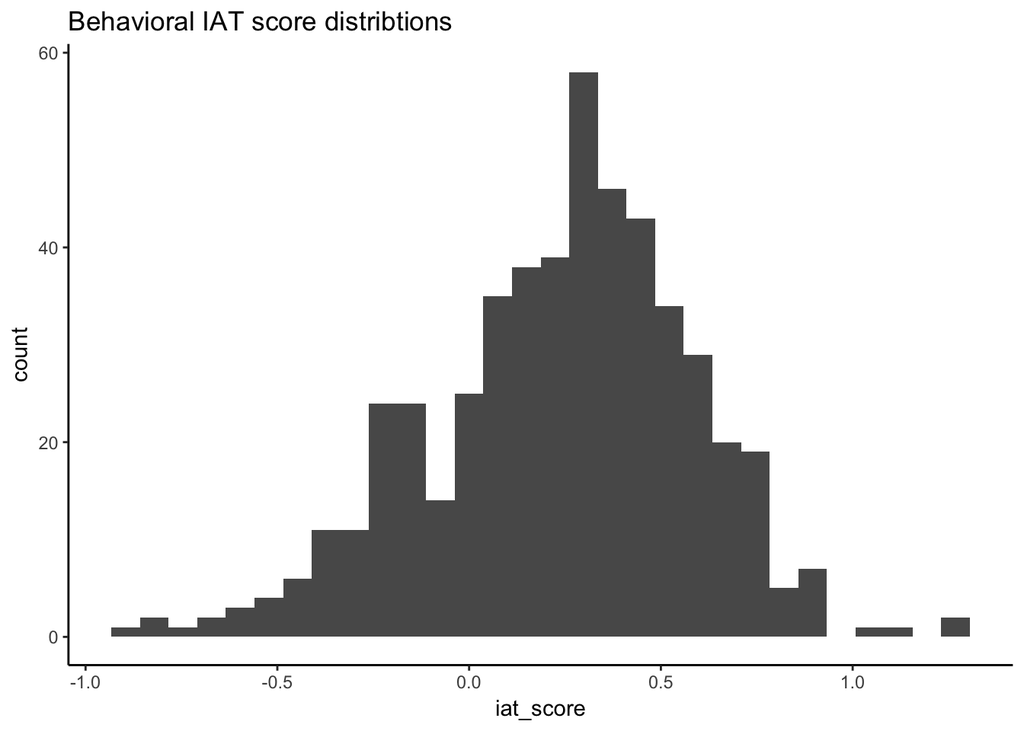

```r
ggplot(IAT_behavioral_tidy_with_resids, aes(x = iat_score)) +
  geom_histogram() +
  ggtitle("Behavioral IAT score distribtions") +
  theme_classic()
```

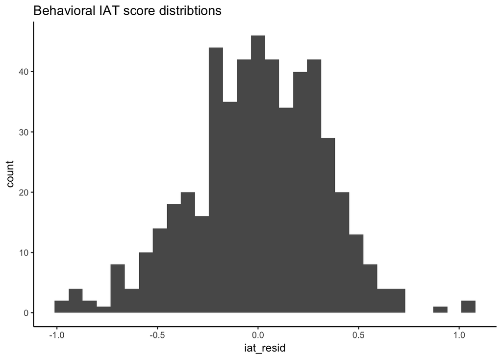

```r
ggplot(IAT_behavioral_tidy_with_resids, aes(x = iat_resid)) +
  geom_histogram() +
  ggtitle("Behavioral IAT score distribtions") +
  theme_classic()
```

## Behavioral IAT vs. Language IAT

### By language

I subset to only those languages that have sufficient speakers. Here the value is set to 8. Here are the mean behavioral IATs by language as a function of language IAT. The ranges are 95% CIs.

#### Predicting raw IAT scores

```r
targ_langs <- lang_counts %>%
  filter(n >= MINPARTICIPANTS) %>%
  pull(lang)

behavioral_means_tidy <- IAT_behavioral_tidy_with_resids %>%
  filter(lang %in% targ_langs) %>%
  group_by(lang) %>%
  multi_boot_standard(col = "iat_score") %>%
  ungroup()  %>%
  rename(behavioral_mean = mean,
         behavioral_ci_lower = ci_lower,
         behavioral_ci_upper = ci_upper)  %>%
  left_join(lang_key %>% select(language_code, lang))

sample_sizes <- count(IAT_behavioral_tidy_with_resids, lang) %>%
    left_join(lang_key %>% select(language_code, lang))

median_age_by_lang <- IAT_behavioral_tidy_with_resids %>%
  group_by(language_code) %>%
  summarize(median_age = mean(median_age))

mean_objectives_by_lang <- IAT_behavioral_tidy_with_resids %>%
  distinct(language_code, country, .keep_all = T) %>%
  select(country, language_code, wps, ggi) %>%
  group_by(language_code) %>%
  summarize(wps = mean(wps, na.rm = T),
            ggi  = mean(ggi, na.rm = T))

full_df <- behavioral_means_tidy %>%
  left_join(IAT_lang_restricted, by = "language_code") %>%
  left_join(sample_sizes, by = "language_code")  %>%
  left_join(median_age_by_lang, by = "language_code") %>%
  left_join(mean_objectives_by_lang, by = "language_code")
```

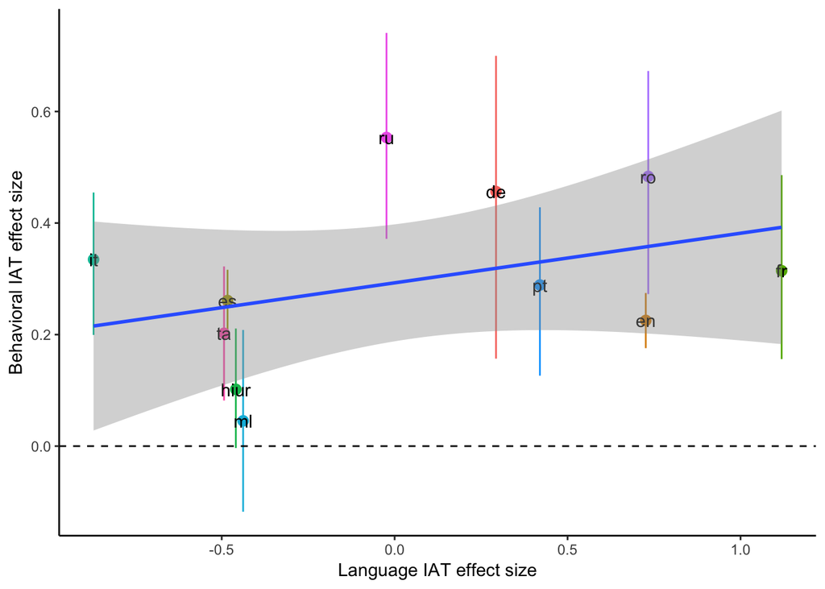

```r
ggplot(full_df, aes(x = effect_size_restricted, y = behavioral_mean)) +
  geom_pointrange(aes(color = language_code, ymin = behavioral_ci_lower, ymax = behavioral_ci_upper)) +
  geom_text(aes(label = language_code)) +
  xlab("Language IAT effect size") +
  ylab("Behavioral IAT effect size") +
  geom_smooth(method = "lm") +
  geom_hline(aes(yintercept = 0), linetype = 2) +
  theme_classic() +
  theme(legend.position = "none")
```

Models

```r
cor.test(full_df$behavioral_mean,
                full_df$effect_size_restricted)
```

```
##
##  Pearson's product-moment correlation
##
## data:  full_df$behavioral_mean and full_df$effect_size_restricted
## t = 1.188, df = 9, p-value = 0.2652
## alternative hypothesis: true correlation is not equal to 0
## 95 percent confidence interval:
##  -0.2973699  0.7929289
## sample estimates:
##       cor
## 0.3681834
```

```r
lm(behavioral_mean ~ effect_size_restricted + median_age, full_df %>% mutate_if(is.numeric, scale)) %>%
  summary()
```

```
##
## Call:
## lm(formula = behavioral_mean ~ effect_size_restricted + median_age,
##     data = full_df %>% mutate_if(is.numeric, scale))
##
## Residuals:
##     Min      1Q  Median      3Q     Max
## -0.6212 -0.4251 -0.2460  0.4239  1.2658
##
## Coefficients:
##                          Estimate Std. Error t value Pr(>|t|)
## (Intercept)            -1.244e-16  2.053e-01   0.000   1.0000
## effect_size_restricted  8.797e-02  2.318e-01   0.379   0.7142
## median_age              7.564e-01  2.318e-01   3.263   0.0115 *
## ---
## Signif. codes:  0 '***' 0.001 '**' 0.01 '*' 0.05 '.' 0.1 ' ' 1
##
## Residual standard error: 0.6809 on 8 degrees of freedom
## Multiple R-squared:  0.6291, Adjusted R-squared:  0.5364
## F-statistic: 6.785 on 2 and 8 DF,  p-value: 0.01892
```

```r
lm(behavioral_mean ~ effect_size_restricted + median_age  + ggi,  full_df %>% mutate_if(is.numeric, scale)) %>%
  summary()
```

```
##
## Call:
## lm(formula = behavioral_mean ~ effect_size_restricted + median_age +
##     ggi, data = full_df %>% mutate_if(is.numeric, scale))
##
## Residuals:
##     Min      1Q  Median      3Q     Max
## -0.6215 -0.4314 -0.2316  0.4280  1.2650
##
## Coefficients:
##                          Estimate Std. Error t value Pr(>|t|)
## (Intercept)            -1.054e-16  2.195e-01   0.000   1.0000
## effect_size_restricted  9.224e-02  2.807e-01   0.329   0.7521
## median_age              7.661e-01  3.903e-01   1.963   0.0905 .
## ggi                    -1.414e-02  4.368e-01  -0.032   0.9751
## ---
## Signif. codes:  0 '***' 0.001 '**' 0.01 '*' 0.05 '.' 0.1 ' ' 1
##
## Residual standard error: 0.7278 on 7 degrees of freedom
## Multiple R-squared:  0.6292, Adjusted R-squared:  0.4702
## F-statistic: 3.959 on 3 and 7 DF,  p-value: 0.06092
```

#### Predicting residualized IAT scores

```r
behavioral_means_tidy <- IAT_behavioral_tidy_with_resids %>%
  filter(lang %in% targ_langs) %>%
  group_by(lang) %>%
  multi_boot_standard(col = "iat_resid") %>%
  ungroup()  %>%
  rename(behavioral_mean = mean,
         behavioral_ci_lower = ci_lower,
         behavioral_ci_upper = ci_upper)  %>%
  left_join(lang_key %>% select(language_code, lang))

full_df <- behavioral_means_tidy %>%
  left_join(IAT_lang_restricted, by = "language_code") %>%
  left_join(sample_sizes, by = "language_code")  %>%
  left_join(median_age_by_lang, by = "language_code")  %>%
  left_join(mean_objectives_by_lang, by = "language_code")
```

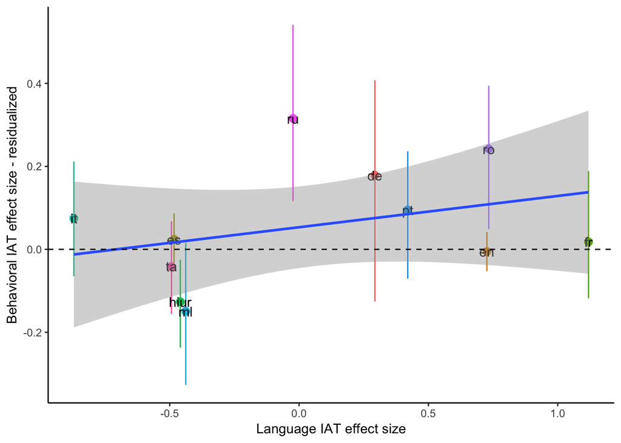

```r
ggplot(full_df, aes(x = effect_size_restricted, y = behavioral_mean)) +
  geom_pointrange(aes(color = language_code, ymin = behavioral_ci_lower, ymax = behavioral_ci_upper)) +
  geom_text(aes(label = language_code)) +
  xlab("Language IAT effect size") +
  ylab("Behavioral IAT effect size - residualized") +
  geom_smooth(method = "lm") +
  geom_hline(aes(yintercept = 0), linetype = 2) +
  theme_classic() +
  theme(legend.position = "none")
```

```r
cor.test(full_df$behavioral_mean,
          full_df$effect_size_restricted)
```

```
##
##  Pearson's product-moment correlation
##
## data:  full_df$behavioral_mean and full_df$effect_size_restricted
## t = 1.0733, df = 9, p-value = 0.3111
## alternative hypothesis: true correlation is not equal to 0
## 95 percent confidence interval:
##  -0.3296283  0.7792635
## sample estimates:
##      cor
## 0.336855
```

```r
lm(behavioral_mean ~ effect_size_restricted + median_age  + ggi,  full_df %>% mutate_if(is.numeric, scale)) %>%
  summary()
```

```
##
## Call:
## lm(formula = behavioral_mean ~ effect_size_restricted + median_age +
##     ggi, data = full_df %>% mutate_if(is.numeric, scale))
##
## Residuals:
##     Min      1Q  Median      3Q     Max
## -0.8239 -0.4224 -0.2897  0.2904  1.4463
##
## Coefficients:
##                          Estimate Std. Error t value Pr(>|t|)
## (Intercept)            -2.205e-16  2.453e-01   0.000    1.000
## effect_size_restricted  4.459e-02  3.138e-01   0.142    0.891
## median_age              6.200e-01  4.363e-01   1.421    0.198
## ggi                     1.121e-01  4.883e-01   0.230    0.825
##
## Residual standard error: 0.8136 on 7 degrees of freedom
## Multiple R-squared:  0.5366, Adjusted R-squared:  0.3381
## F-statistic: 2.702 on 3 and 7 DF,  p-value: 0.1258
```

### Predicting IAT Language Variability

```r
cor.test(full_df$effect_size_restricted, full_df$ggi)
```

```
##
##  Pearson's product-moment correlation
##
## data:  full_df$effect_size_restricted and full_df$ggi
## t = 2.0163, df = 9, p-value = 0.07456
## alternative hypothesis: true correlation is not equal to 0
## 95 percent confidence interval:
##  -0.06320374  0.86743295
## sample estimates:
##       cor
## 0.5578207
```

```r
cor.test(full_df$effect_size_restricted, full_df$wps)
```

```
##
##  Pearson's product-moment correlation
##
## data:  full_df$effect_size_restricted and full_df$wps
## t = 1.6178, df = 9, p-value = 0.1402
## alternative hypothesis: true correlation is not equal to 0
## 95 percent confidence interval:
##  -0.1750726  0.8363819
## sample estimates:
##       cor
## 0.4746511
```

### By participant

This is the same analysis as above, but at the participant level using mixed-effect models.

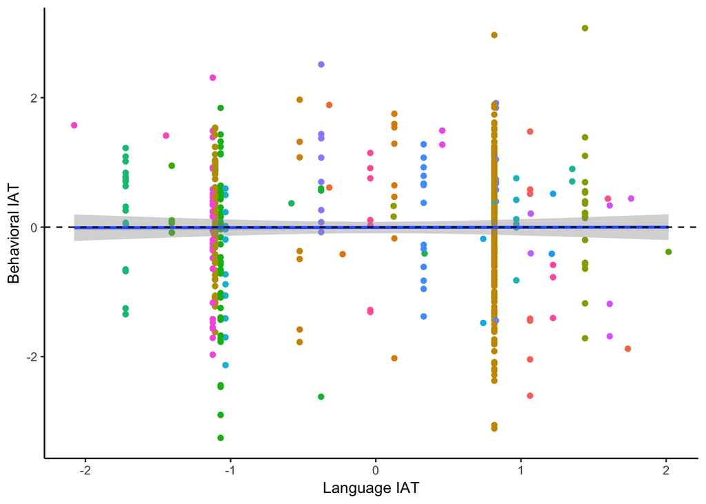

```r
by_participant_df <-  IAT_behavioral_tidy_with_resids  %>%
   left_join(IAT_lang_restricted, by = "language_code") %>%
   mutate(effect_size_restricted = scale(effect_size_restricted),
          log_age = scale(log_age),
          iat_score = scale(iat_score),
          iat_resid = scale(iat_resid),
          condition = as.factor(condition),
          median_age = scale(median_age))

ggplot(by_participant_df, aes(x = effect_size_restricted,
                     y = iat_score)) +
  geom_point(aes( color = language_code)) +
  geom_smooth(method = "lm") +
  ylab("Behavioral IAT") +
  xlab("Language IAT") +
  geom_hline(aes(yintercept = 0), linetype = 2) +
  theme_classic() +
  theme(legend.position = "none")
```

In a mixed-effect model with country and language as random intercepts and gender and age as fixed effect, here’s no relationship between language IAT and behavioral IAT when you include all languages. All variables are scaled.

```r
lme4::lmer(iat_score ~ effect_size_restricted+ gender + log_age + condition + (1|country)  + (1|lang),
           by_participant_df) %>%
  summary()
```

```
## Linear mixed model fit by REML ['lmerMod']
## Formula:
## iat_score ~ effect_size_restricted + gender + log_age + condition +
##     (1 | country) + (1 | lang)
##    Data: by_participant_df
##
## REML criterion at convergence: 1381.9
##
## Scaled residuals:
##      Min       1Q   Median       3Q      Max
## -2.93410 -0.62122  0.03456  0.68683  3.14900
##
## Random effects:
##  Groups   Name        Variance Std.Dev.
##  country  (Intercept) 0.01404  0.1185
##  lang     (Intercept) 0.03937  0.1984
##  Residual             0.89111  0.9440
## Number of obs: 497, groups:  country, 74; lang, 39
##
## Fixed effects:
##                        Estimate Std. Error t value
## (Intercept)            -0.39919    0.11252  -3.548
## effect_size_restricted -0.04515    0.06999  -0.645
## gendermale              0.23932    0.09427   2.539
## log_age                -0.02783    0.04276  -0.651
## condition1              0.56059    0.08627   6.498
##
## Correlation of Fixed Effects:
##             (Intr) effc__ gndrml log_ag
## effct_sz_rs  0.013
## gendermale  -0.621  0.019
## log_age     -0.006  0.002  0.037
## condition1  -0.406  0.007  0.008 -0.027
```

```r
lme4::lmer(iat_score ~ effect_size_restricted* gender + log_age + condition + (1|country)  + (1|lang),
           by_participant_df) %>%
  summary()
```

```
## Linear mixed model fit by REML ['lmerMod']
## Formula:
## iat_score ~ effect_size_restricted * gender + log_age + condition +
##     (1 | country) + (1 | lang)
##    Data: by_participant_df
##
## REML criterion at convergence: 1383.9
##
## Scaled residuals:
##      Min       1Q   Median       3Q      Max
## -2.91782 -0.63305  0.02894  0.67509  3.06333
##
## Random effects:
##  Groups   Name        Variance Std.Dev.
##  country  (Intercept) 0.01352  0.1163
##  lang     (Intercept) 0.04214  0.2053
##  Residual             0.89079  0.9438
## Number of obs: 497, groups:  country, 74; lang, 39
##
## Fixed effects:
##                                   Estimate Std. Error t value
## (Intercept)                       -0.40120    0.11310  -3.547
## effect_size_restricted             0.01690    0.09816   0.172
## gendermale                         0.24369    0.09440   2.581
## log_age                           -0.02719    0.04276  -0.636
## condition1                         0.55538    0.08644   6.425
## effect_size_restricted:gendermale -0.08723    0.09426  -0.925
##
## Correlation of Fixed Effects:
##             (Intr) effc__ gndrml log_ag cndtn1
## effct_sz_rs -0.009
## gendermale  -0.618  0.051
## log_age     -0.006  0.011  0.037
## condition1  -0.401 -0.036  0.005 -0.028
## effct_sz_r:  0.026 -0.692 -0.054 -0.014  0.060
```

This is true even when you exclude participants.

```r
targ_langs <- lang_counts %>%
  filter(n >= MINPARTICIPANTS) %>%
  pull(lang)

lme4::lmer(iat_score ~ effect_size_restricted+ gender + log_age + condition + (1|country)  + (1|lang),
           by_participant_df %>% filter(lang %in% targ_langs)) %>%
  summary()
```

```
## Linear mixed model fit by REML ['lmerMod']
## Formula:
## iat_score ~ effect_size_restricted + gender + log_age + condition +
##     (1 | country) + (1 | lang)
##    Data: by_participant_df %>% filter(lang %in% targ_langs)
##
## REML criterion at convergence: 1175.2
##
## Scaled residuals:
##      Min       1Q   Median       3Q      Max
## -2.88721 -0.61025 -0.00123  0.68786  3.00306
##
## Random effects:
##  Groups   Name        Variance Std.Dev.
##  country  (Intercept) 0.02504  0.1582
##  lang     (Intercept) 0.02456  0.1567
##  Residual             0.87737  0.9367
## Number of obs: 425, groups:  country, 53; lang, 11
##
## Fixed effects:
##                        Estimate Std. Error t value
## (Intercept)            -0.26330    0.12336  -2.134
## effect_size_restricted  0.05143    0.08111   0.634
## gendermale              0.16019    0.09947   1.610
## log_age                -0.04323    0.04498  -0.961
## condition1              0.57120    0.09254   6.172
##
## Correlation of Fixed Effects:
##             (Intr) effc__ gndrml log_ag
## effct_sz_rs  0.157
## gendermale  -0.563  0.014
## log_age     -0.028  0.026  0.032
## condition1  -0.381 -0.041 -0.017 -0.021
```

```r
lme4::lmer(iat_score ~ effect_size_restricted*gender + log_age + condition + (1|country)  + (1|lang),
           by_participant_df %>% filter(lang %in% targ_langs)) %>%
  summary()
```

```
## Linear mixed model fit by REML ['lmerMod']
## Formula:
## iat_score ~ effect_size_restricted * gender + log_age + condition +
##     (1 | country) + (1 | lang)
##    Data: by_participant_df %>% filter(lang %in% targ_langs)
##
## REML criterion at convergence: 1175.8
##
## Scaled residuals:
##      Min       1Q   Median       3Q      Max
## -2.86373 -0.63056 -0.01102  0.66263  2.85882
##
## Random effects:
##  Groups   Name        Variance Std.Dev.
##  country  (Intercept) 0.02313  0.1521
##  lang     (Intercept) 0.02960  0.1720
##  Residual             0.87450  0.9351
## Number of obs: 425, groups:  country, 53; lang, 11
##
## Fixed effects:
##                                   Estimate Std. Error t value
## (Intercept)                       -0.25996    0.12541  -2.073
## effect_size_restricted             0.16042    0.11002   1.458
## gendermale                         0.16184    0.09932   1.630
## log_age                           -0.04282    0.04490  -0.954
## condition1                         0.56269    0.09255   6.080
## effect_size_restricted:gendermale -0.14930    0.10068  -1.483
##
## Correlation of Fixed Effects:
##             (Intr) effc__ gndrml log_ag cndtn1
## effct_sz_rs  0.127
## gendermale  -0.552  0.017
## log_age     -0.027  0.024  0.032
## condition1  -0.374 -0.067 -0.018 -0.021
## effct_sz_r:  0.004 -0.640 -0.012 -0.008  0.055
```